# Basic Plotting

```matlab
x=[0:2:18]
```

```
x =

     0     2     4     6     8    10    12    14    16    18
```

```matlab
y=[0 0.33 4.1 6.3 6.85 11.2 13.2 13.96 16.3 18.2]
```

```
y =

         0    0.3300    4.1000    6.3000    6.8500   11.2000   13.2000   13.9600   16.3000   18.2000
```

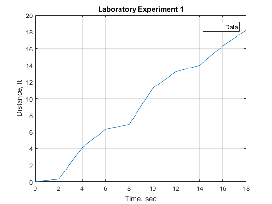

```matlab
plot(x,y)
title('Laboratory Experiment 1')
xlabel('Time, sec')
ylabel('Distance, ft')
legend('Data')
grid on
```

# Plots with More Than One Line

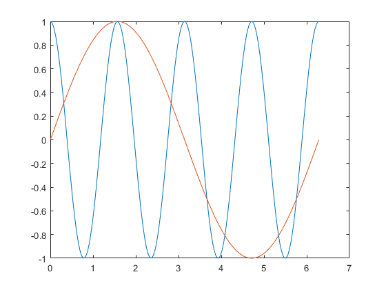

```matlab
x = 0:pi/100:2*pi;
y1 = cos(x*4);
y2 = sin(x);

plot(x,y1) % First way
hold on
plot (x,y2)
hold off
```

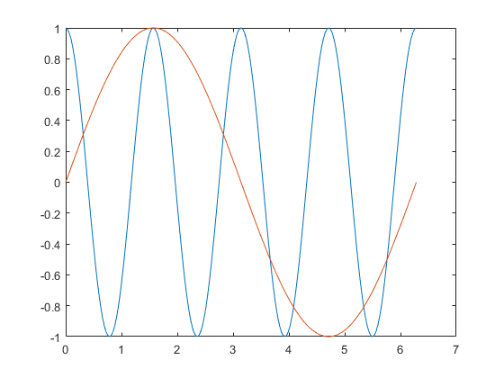

```matlab
plot(x,y1,x,y2) % Second way
```

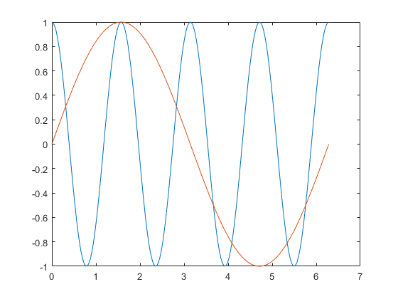

```matlab
Y=[y1;y2]; % Third way
plot(x,Y)
```

# Line, Mark, and Color Options

|  | COLOR |  |  | MARK |  |  | LINE |
| --- | --- | --- | --- | --- | --- | --- | --- |
| b | blue |  | . | point |  | - | solid |
| g | green |  | o | circle |  | : | dotted |
| r | red |  | x | x-mark |  | -. | dashdot |
| c | cyan |  | + | plus |  | -- | dashed |
| m | magenta |  | * | star |  | (none) | no line |
| y | yellow |  | s | square |  |  |  |
| k | black |  | d | diamond |  |  |  |
| w | white |  | v | triangle (down) |  |  |  |
|  |  |  | ˆ | triangle (up) |  |  |  |
|  |  |  | < | triangle (left) |  |  |  |
|  |  |  | > | triangle (right) |  |  |  |
|  |  |  | p | pentagram |  |  |  |
|  |  |  | h | hexagram |  |  |  |

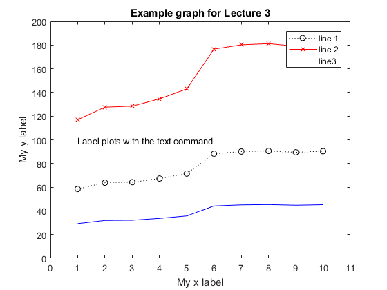

```matlab
x=[1:10];
y=[58.5 63.8 64.2 67.3 71.5 88.3 90.1 90.6 89.5 90.4];
plot(x, y, ':ok', x, y*2, '-xr', x, y/2, '-b')
legend('line 1', 'line 2', 'line3')
text(1,100,'Label plots with the text command')
xlabel('My x label')
ylabel('My y label')
title('Example graph for Lecture 3')
axis([0,11,0,200])
```

# Axis Scaling, and Annotating Plots

- `axis` : When the axis function is used without inputs, it freezes the axis at the current configuration. Executing the function a second time returns axis control to MATLAB
- `axis(v)` : The input to the axis command (v) must be a four-element vector that specifies the minimum and maximum values for both the x and y axes for example, [xmin, xmax, ymin, ymax].
- `axis equal` : Forces the scaling on the x and y axes to be the same.
- `legend('string1', 'string 2', etc)` : Allows you to add a legend to your graph. The legend shows a sample of the line and lists the string you have specified.
- `text(x-coordinate, y-coordinate, 'string')` : Allows you to add a text box to the graph. The box is placed at the specified x and y coordinates and contains the string value specified.
- `gtext('string')` : Similar to text. The box is placed at a location determined interactively by the user by clicking in the figure window.

# Subplots

`subplot(m, n, p)` : Allows you to subdivide the graphing window into a grid of m rows and n columns.

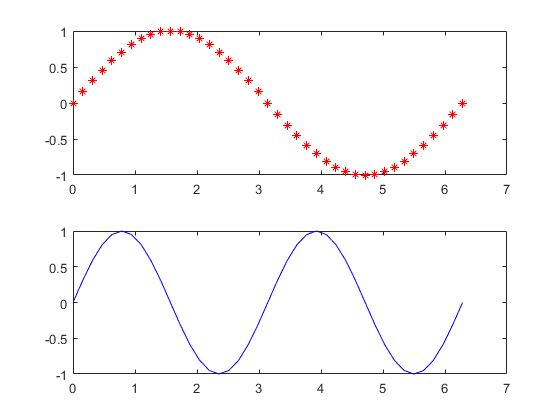

```matlab
x = 0:pi/20:2*pi;
subplot(2,1,1)
plot(x, sin(x), '*r')
subplot(2,1,2)
plot(x, sin(2*x), '-b')
```

# Polar Plots

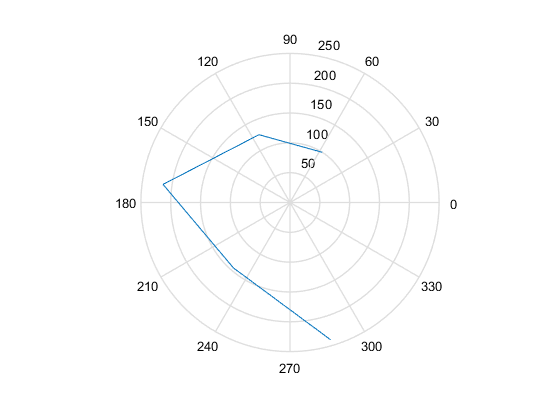

```matlab
x = [1 2 3 4 5];
y = [100 125 215 145 240];
polar(x,y)
```

# Logarithmic Plots

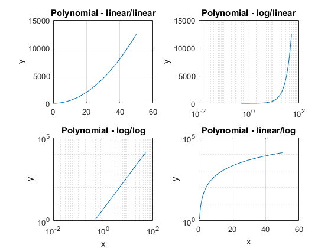

```matlab
x = 0:0.5:50;
y = 5*x.^2;

subplot(2,2,1)
plot(x,y)
title('Polynomial - linear/linear')
ylabel('y'), grid

subplot(2,2,2)
semilogx(x,y)
title('Polynomial - log/linear')
ylabel('y'), grid

subplot(2,2,3)
loglog(x,y)
title('Polynomial - log/log')
xlabel('x'), ylabel('y'), grid

subplot(2,2,4)
semilogy(x,y)
title('Polynomial - linear/log')
xlabel('x'), ylabel('y'), grid
```

# Bar Graphs, Pie Charts, Histograms

- `bar(x)` : When x is a vector, bar generates a vertical bar graph. When x is a two-dimensional matrix, bar groups the data by row.
- `barh(x)` : When x is a vector, barh generates a horizontal bar graph. When x is a two-dimensional matrix, barh groups the data by row.
- `bar3(x)` : Generates a three-dimensional bar chart.
- `bar3h(x)` : Generates a three-dimensional horizontal bar chart.
- `pie(x)` : Generates a pie chart. Each element in the matrix is represented as a slice of the pie.
- `pie3(x)` : Generates a three-dimensional pie chart. Each element in the matrix is represented as a slice of the pie.
- `hist(x)` : Generates a histogram.

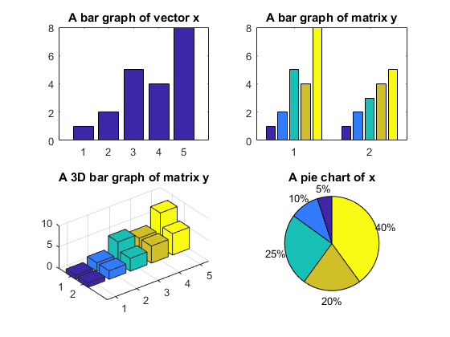

```matlab
x = [1 2 5 4 8];
y = [x;1:5];
subplot(2,2,1)
bar(x), title('A bar graph of vector x')
subplot(2,2,2)
bar(y), title('A bar graph of matrix y')
subplot(2,2,3)
bar3(y), title('A 3D bar graph of matrix y')
subplot(2,2,4)
pie(x), title('A pie chart of x')
```

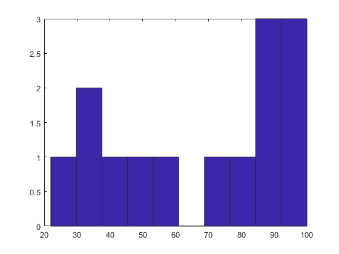

```matlab
x = [100 95 74 87 22 78 34 35 93 88 86 42 55 48];
hist(x)
```

# x-y Graphs with Two y-axes

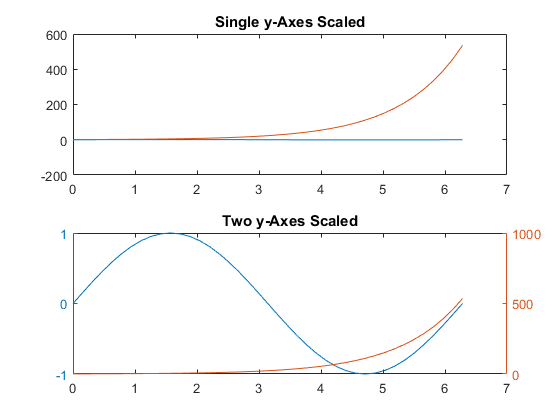

```matlab
x = 0:pi/20:2*pi;
y1 = sin(x);
y2 = exp(x);
subplot(2,1,1)
plot(x, y1 ,x ,y2)
title('Single y-Axes Scaled')
subplot(2,1,2)
plotyy(x, y1, x, y2)
title('Two y-Axes Scaled')
```

# Function Plots

`fplot` : Allows you to plot a function without defining arrays of corresponding x and y values.

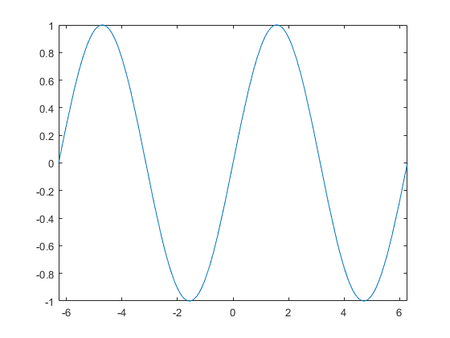

```matlab
fplot('sin(x)',[-2*pi,2*pi])
```

# Three-Dimensional Plots

- `plot3(x,y,z)` : Creates a three-dimensional line plot.
- `comet3(x,y,z)` : Generates an animated version of plot3.
- `mesh(z)` or `mesh(x,y,z)` : Creates a meshed surface plot.
- `surf(z)` or `surf(x,y,z)` : Creates a surface plot; similar to the mesh function.
- `shading interp` : Interpolates between the colors used to illustrate surface plots.
- `shading flat` : Colors each grid section with a solid color.
- `colormap(map-name)` : Allows the user to select the color pattern used on surface plots.
- `contour(z)` or `contour(x,y,z)` : Generates a contour plot.
- `surfc(z)` or `surfc(x,y,z)` : Creates a combined surface plot and contour plot.
- `pcolor(z)` or `pcolor(x,y,z)` : Creates a pseudo color plot.